# Ranks and dominant species

Niklas Hausmann

02/07/2020

## Introduction

To determine the dominant species at all sites, we make use of the shell weight dataframe ‘Species’ from the earlier walkthrough. If you don’t have this already you can run through this code:

```r
library(here)
# library(tidyr)
# library(dplyr)
library(tidyverse)

Species <- read.csv(here("data/Species.csv"))

Species$Weight[Species$Weight == 0.5] <- 0.25


Species <- Species %>%
  group_by(Site, Sample, Speciesname) %>%
  summarise(Weight = sum(Weight)) %>%
  spread(Speciesname, Weight, fill = 0)

Species <-
  aggregate(Species[, 3:97], by = list(Site = Species$Site), FUN = sum)

Species <- Species %>%
  separate(Site, sep = 6, into = "Site") %>%
  group_by(Site) %>%
  summarise_each(funs(sum))

library(janitor)

Species <- add_totals_col(Species) %>%
  rename(Total_weight = Total)
```

## Species abundances across sites

For the analysis of the shell species’ weight-percentages and their individual ranks (with rank 1 for the most common species) at each site, we make use of the `BiodiversityR`-package. For that we first need to remove the column with site names, because `BiodiversityR` doesn’t know what to do with those. For convenience they are moved into the rownames. `BiodiversityR` also requires integers to work. Our dataset uses decimal numbers, so we need to round these weights to the nearest gram to create the dataframe ‘SpeciesRound’.

```r
SpeciesRound <- column_to_rownames(Species,var="Site")

SpeciesRound <- round(SpeciesRound[,1:95])#this step rounds the data and also drops the total weights in the last column of Species
```

In the next step, we will determine the ranks for each row (i.e. site) in a for-loop and using the `rankabundance` function in the [`BiodiversityR`](https://rdrr.io/cran/BiodiversityR/) package.

```r
# Either load the whole package
# library(BiodiversityR)
# or load the rankabundance() function which is in the code folder
source('rankabundance.R')

Ranks <- data.frame() #main dataframe
Rank <- data.frame() #single site dataframe used temporarily for each row's loop

for (i in 1:length(SpeciesRound[,1])) {

  Rank<- rankabundance(SpeciesRound[i,])#make ranking of species abundance. This step will produce a lof of NaNs but that is ok
  Rank <- subset(Rank, Rank[,2] != 0, select=c(rank, abundance, proportion, logabun)) #remove unneccesary colums and rows with species = 0
  Rank <- data.frame(Rank,Site=rep(rownames(SpeciesRound[i,]),c(length(Rank[,1]))), SpeciesRound=rownames(Rank))

  Ranks <- rbind(Ranks,Rank)
}

rm(Rank,i)#no need for this after the loop is finished
```

The results are given for each species in each midden. The species that do not occur in a specific midden were dropped, as well as some of the statistical data that `rankabundance` produces. In the end, we are left with the species, it’s rank within the site, the abundance in grams and as logarythm, the proportion in %, and the site they belong to.

```r
Ranks[1:2,1:5]
```

```
##                       rank abundance proportion logabun   Site
## Chicoreus species        1       558       46.2     2.7 JE0003
## Pleuroploca trapezium    2       282       23.3     2.5 JE0003
```

To only look at the dominant species’ weight for each site, we `spread` this dataframe and remove the species that are not dominant. This selection of ‘dominant’ is done manually and is mainly based on the proportion (>10%) of a species overall, but we also included species that are dominant in only one or two sites (i.e. Pleuroploca trapezium).

```r
Ranks <- Ranks %>%
  spread(SpeciesRound, proportion, fill = 0) %>% #keep in mind that 'Species' is the column within the Ranks dataframe, not the Species dataframe.
  select(
    'Site',
    'Conomurex fasciatus',
    'Pinctada species',
    'Chicoreus species',
    'Chama species',
    'Spondylus species',
    'Strombus tricornis',
    'Plicatula plicata',
    'Arca species',
    'Pleuroploca trapezium',
    'Ostrea species'
  ) #this step cuts down a lot of the columns (species) and leaves only the important ones.


Ranks <- aggregate(Ranks[,2:11],by=list(Site=Ranks$Site),FUN=sum) #this step is necessary to combine all of a site's rows into one row. Before we had one row per site and species, but they can easily be added up with the aggregate function (sum).

rm(SpeciesRound)

head(Ranks) #This is the data found in Table 2
```

```
##     Site Conomurex fasciatus Pinctada species Chicoreus species Chama species
## 1 JE0003                18.2              8.9              46.2           0.7
## 2 JE0004                64.2              7.5              15.6           5.2
## 3 JE0078                85.9              0.3               8.6           4.3
## 4 JE0087                98.0              0.4               1.6           0.0
## 5 JE5642                91.6              0.8               2.0           3.1
## 6 JW0001                68.0              0.3               3.4           0.7
##   Spondylus species Strombus tricornis Plicatula plicata Arca species
## 1               0.8                  0               0.5          0.0
## 2               3.8                  0               2.0          0.1
## 3               0.2                  0               0.4          0.0
## 4               0.0                  0               0.1          0.0
## 5               0.9                  0               0.4          0.0
## 6               0.0                 13               0.0          3.7
##   Pleuroploca trapezium Ostrea species
## 1                  23.3            0.0
## 2                   0.0            0.5
## 3                   0.0            0.0
## 4                   0.0            0.0
## 5                   0.1            0.0
## 6                   0.0            0.9
```

## Illustrating species abundance across sites (Fig.4)

To show these data more clearly, we created Figure 4, which shows the species distribution by site and clustered by bay area. However, first we need to change the structure of the `Ranks` dataframe using the `gather` function, which is part of the [Tidyverse](https://www.tidyverse.org) package. #This step takes each row and distributes the individual values for weight into several new rows, which are then structured by a key variable (Species).

```r
#First we will add the Bay Area to each site, as this will help to group the data later.
Ranks <- Ranks %>%
  mutate(Area = ifelse(grepl("KM", Site),"Khur Maadi",
                  ifelse(grepl("JW", Site), "Janaba West", "Janaba East")
  ))

# Transform data into a long format for Figure 4
Fig4Dat <- Ranks %>%
  gather(key = "Species", value="Weight",2:11)

head(Fig4Dat)
```

```
##     Site        Area             Species Weight
## 1 JE0003 Janaba East Conomurex fasciatus   18.2
## 2 JE0004 Janaba East Conomurex fasciatus   64.2
## 3 JE0078 Janaba East Conomurex fasciatus   85.9
## 4 JE0087 Janaba East Conomurex fasciatus   98.0
## 5 JE5642 Janaba East Conomurex fasciatus   91.6
## 6 JW0001 Janaba West Conomurex fasciatus   68.0
```

With the data restructured, we will make a stacked bar chart for each area using ggplot, and add them together into one figure (Fig. 4) using `patchwork`.

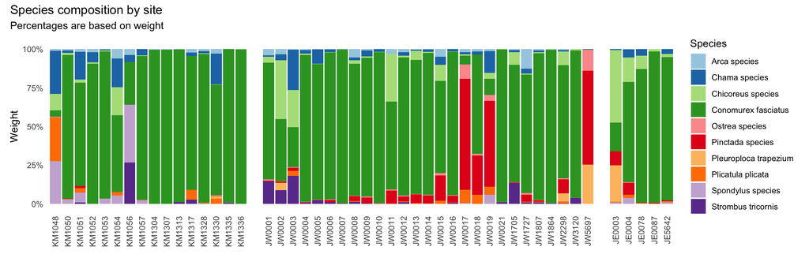

```r
library("ggplot2")
library("RColorBrewer")
library("patchwork")


KM <- Fig4Dat %>%
  filter(Area=="Khur Maadi") %>%
  ggplot() +
  geom_bar(aes(x = Site, y = Weight, fill = Species),
           position = "fill",
           stat = "identity") +
  theme_minimal() +   scale_fill_brewer(palette = "Paired") +
  theme(
    axis.text.x = element_text(
      angle = 90,
      hjust = 1,
      vjust = 0.5
    ),
    panel.grid.major = element_blank(),
    panel.grid.minor = element_blank(),
    panel.background = element_blank(),
    legend.position = "none"
  ) + xlab("") +
  scale_y_continuous(labels = c("0%", "25%", "50%", "75%", "100%"))

JW <-  Fig4Dat %>%
  filter(Area=="Janaba West") %>%
  ggplot() +
  geom_bar(aes(x = Site, y = Weight, fill = Species),
           position = "fill",
           stat = "identity") +
  theme_minimal() +   scale_fill_brewer(palette = "Paired") +
  theme(
    axis.text.x = element_text(
      angle = 90,
      hjust = 1,
      vjust = 0.5
    ),
    axis.title.y = element_blank(),
    axis.text.y = element_blank(),
    axis.ticks.y = element_blank(),
    panel.grid.major = element_blank(),
    panel.grid.minor = element_blank(),
    panel.background = element_blank(),
    legend.position = "none"
  ) + xlab("") + ylab("")



JE <- Fig4Dat %>%
  filter(Area=="Janaba East") %>%
  ggplot() +
  geom_bar(aes(x = Site, y = Weight, fill = Species),
           position = "fill",
           stat = "identity") +
  theme_minimal() +   scale_fill_brewer(palette = "Paired") +
  theme(
    axis.text.x = element_text(
      angle = 90,
      hjust = 1,
      vjust = 0.5
    ),
    axis.title.y = element_blank(),
    axis.text.y = element_blank(),
    axis.ticks.y = element_blank(),
    panel.grid.major = element_blank(),
    panel.grid.minor = element_blank(),
    panel.background = element_blank()
  ) + xlab("") + ylab("")


Fig4 <- KM + JW + JE +
        plot_layout(widths = c(3,5,1))+
        plot_annotation(
        title = 'Species composition by site',
        subtitle = 'Percentages are based on weight')
Fig4
```

```r
ggsave(
  here("/Figures and supplementary material/Figure_4.png"),
  plot = Fig4,
  height = 100,
  width = 300,
  units = "mm"
)
```

## Dominant species by bay area (Fig.5)

To show the general abundances of species in different areas around Farasan, we structured the shell weight data by areas instead of sites.

```r
Species <- Species %>%
           mutate(Area = ifelse(grepl("KM", Site),"Khur Maadi",
                  ifelse(grepl("JW", Site), "Janaba West", "Janaba East")))

Species <- aggregate(Species[,2:97], by=list(Area=Species$Area), FUN = sum) %>% #this aggregates all weights by Area
  arrange(desc(Area))

SpeciesRound <- column_to_rownames(Species,var="Area")

SpeciesRound <- round(SpeciesRound[,1:95])

head(SpeciesRound[,c(9,19,20)])
```

```
##             Atactodea species Chama species Chicoreus species
## Khur Maadi                  0          3755               678
## Janaba West                 0          2705              4456
## Janaba East               169          2889              8062
```

Similar to above, we use the `BiodiversityR` package to rank the species by weight. This time the ranks apply to the bay area as a whole.

```r
AreaRanks <- data.frame()
AreaRank <- data.frame()

for (i in 1:length(SpeciesRound[,1])) {

  AreaRank<- rankabundance(SpeciesRound[i,])
  AreaRank <- subset(AreaRank, AreaRank[,2] != 0, select=c(rank, abundance, proportion)) #remove unneccesary colums and rows with species = 0
  AreaRank <- data.frame(AreaRank,Area=rep(rownames(SpeciesRound[i,]),c(length(AreaRank[,1]))), Species=rownames(AreaRank))

  AreaRanks <- rbind(AreaRanks,AreaRank)
}
```

We then added a `Dominant` column at the back, where species are considered dominant when they are above 2%. This is an arbitrary number. Of course C. fasciatus is THE dominant species in all areas, but the species above 2% are still occurring in respectable numbers compared to many other species.

```r
AreaRanks <- AreaRanks %>%
            mutate(Dominant=ifelse(AreaRanks$proportion <2, "Marginal","Dominant"))
```

Lastly, to create Figure 5, we use the `ggplot2` package again, as well as ggrepel, so help with the labels.

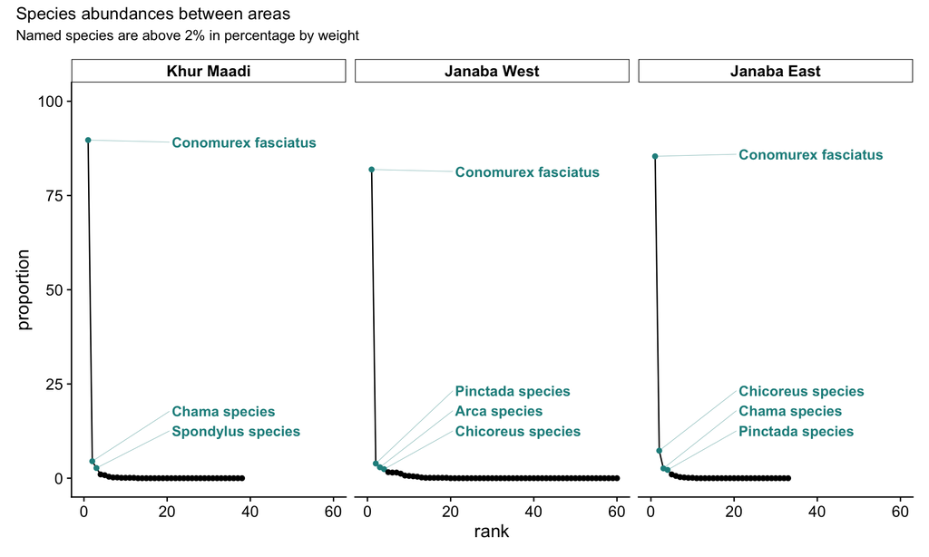

```r
library(ggplot2)
library(viridis)
library(cowplot)
library(ggrepel)
library(patchwork)


Fig5 <-  AreaRanks %>%
  ggplot(aes(x = rank, y = proportion, group = Area)) +
  geom_path(size = 0.5) +
  geom_point(aes(color = Dominant), show.legend = FALSE) +
  scale_color_manual(values = c(viridis_pal()(60)[30], "black")) + xlim(0, 60) + ylim(0, 100) +
  theme(legend.position = "none") + facet_wrap( ~ Area, nrow = 1) + theme_half_open() +
  theme(strip.background = element_rect(colour = "black", fill = "white")) +
  theme(strip.text.x = element_text(face = "bold")) +
  geom_text_repel(
    data = subset(AreaRanks, proportion > 2),
    aes(label = Species, color = factor(Species)),
    xlim = c(20, 60),
    ylim = c(10, NA),
    colour = viridis_pal()(60)[30],
    direction = "y",
    hjust = 0,
    segment.size = 0.1,
    fontface = 'bold'
  )



Fig5 + plot_annotation(title = 'Species abundances between areas',
                       subtitle = 'Named species are above 2% in percentage by weight')
```

```r
ggsave(
  here("/Figures and supplementary material/Figure_5.png"),
  plot = Fig5,
  height = 150,
  width = 300,
  units = "mm"
)
```